# Day 9 Bootstrapping and Cross Validation

# for loop

```r
for (i in 1:5){
  print (i)
}
```

```
[1] 1
[1] 2
[1] 3
[1] 4
[1] 5
```

```r
sum_i = 0

for (i in 1:5){
  sum_i = sum_i + i
  print(sum_i)
}
```

```
[1] 1
[1] 3
[1] 6
[1] 10
[1] 15
```

```r
sum_i <- 0
for (i in 1:5) sum_i <- sum_i+i; print(sum_i)
```

```
[1] 15
```

## Using a for loop to run repeated samplings

```r
set.seed(111)
data = rnorm(n=20, mean = 120, sd=10)
```

## mean of sample

```r
mean(data)
```

```
[1] 116.4629
```

## standard error of sample mean

```r
standard_error
```

```
[1] 2.055603
```

## standard error of population

```r
10/sqrt(20)
```

```
[1] 2.236068
```

# 95% CI

```r
upper_limit
```

```
[1] 120.5741
```

```r
lower_limit
```

```
[1] 112.3517
```

## Repeated loops

Draw 100 samples, create empty vector sample_means with 100 entries

```r
set.seed(111)
sample_means = rep(0,100)
for(i in 1:100){
  sim_data = rnorm(n=20, mean = 120, sd=10)
  sample_means[i] = mean(sim_data)
}
```

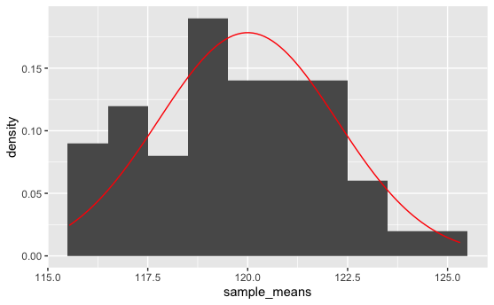

```r
library(tidyverse)

ggplot() +
  geom_histogram(aes(x=sample_means, y= after_stat(density)), binwidth=1) +
  stat_function(fun = dnorm, args=list(mean = 120, sd=10/sqrt(20)), color="red")
```

width (sd) of the distribution is the std error

```r
sd(sample_means)
```

```
[1] 2.249583
```

95% CI

```r
quantile(sample_means, c(0.025, 0.975))
```

```
   2.5%   97.5%
115.645 123.806
```

With greater number of samples

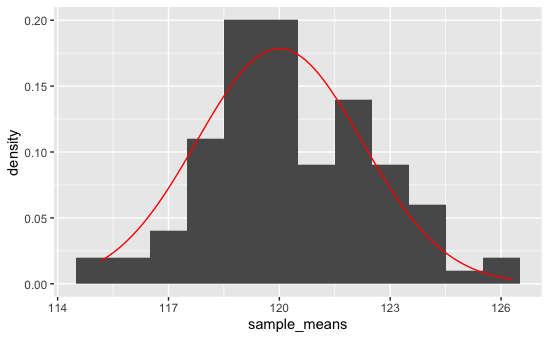

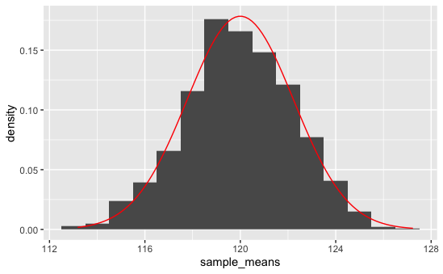

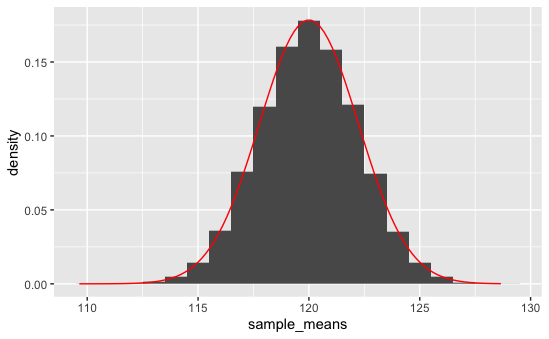

```r
m = c(100,1000,10000)

for (j in 1:3){
  sample_means = rep(0,m[j]) #create that many samples 100, 1000, 10000
  for(i in 1:m[j]){
    sim_data = rnorm(n=20, mean=120, sd=10)
    sample_means[i] = mean(sim_data)
  }
  print(ggplot() +
          geom_histogram(aes(x=sample_means, y=after_stat(density)), binwidth=1) +
          stat_function(fun=dnorm, args=list(mean=120, sd=10/sqrt(20)), color = "red"))
}
```

# Resampling datasets

```r
set.seed(111)
sim_data <- rnorm(n = 20, mean = 120, sd = 10)
bootstrapped_data <- sample(sim_data, size = 20, replace = T)
table(bootstrapped_data)
```

```
bootstrapped_data
96.9765434157062 104.333346398144 105.025733444349 110.515243950476
               3                1                1                1
115.060377827649 116.408605187622 118.291239553861 119.141489911774
               3                1                2                1
121.402782251032 122.352207116137 123.641867370222 138.456362638071
               3                1                2                1
```

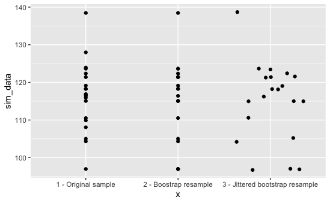

```r
ggplot() +
  geom_point(mapping=aes(y=sim_data, x="1 - Original sample")) +
  geom_point(mapping=aes(y=bootstrapped_data, x="2 - Boostrap resample")) +
  geom_jitter(mapping=aes(y=bootstrapped_data, x="3 - Jittered bootstrap resample"))
```

```r
NA
NA
NA
```

Some of the points are repeated in bootstrap (hence missing points on bootstrap resample) but the number of samples is the same as original. Jittered shows how many times the points are repeated. for example at 115, boostrap resample 3 times

We can repeat the resampling many times to construct a distribution of results:

```r
sim_data <- rnorm(n = 20, mean = 120, sd = 10)

bootstrapped_means <- rep(0, 100)

for (i in 1:100){
  bootstrapped_data <- sample(sim_data, size = 20, replace = T)
  bootstrapped_means[i] <- mean(bootstrapped_data)
}
```

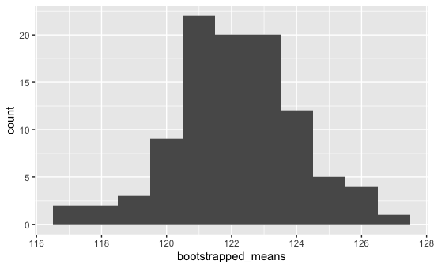

```r
ggplot() +
  geom_histogram(mapping=aes(x=bootstrapped_means), binwidth=1)
```

# Applying the bootstrap method to quantify the uncertainty in model coefficients

```r
library(tidyverse)

select <- dplyr::select

female_labels <- c("male","female")
race_labels <- c("hispanic", "asian", "african-american", "white")
ses_labels <- c("low", "middle", "high")
schtyp_labels <- c("public","private")
prog_labels <- c("general", "academic", "vocational")

highschool <- read_csv("/Users/pp16/Desktop/NTU/UCL exchange/week 1 day 3/hsb2.csv", col_types = "dfffffddddd") %>%
  mutate(gender = factor(female, levels = c(0,1),labels = female_labels),
         race = factor(race, levels = c(1,2,3,4), labels = race_labels),
         ses = factor(ses, levels = c(1,2,3),labels = ses_labels),
         schtyp = factor(schtyp, levels = c(1,2), labels = schtyp_labels),
         prog = factor(prog, levels = c(1,2,3), labels = prog_labels)
         ) %>%
  select(-female)
glimpse(highschool)
```

```
Rows: 200
Columns: 11
$ id      <dbl> 70, 121, 86, 141, 172, 113, 50, 11, 84, 48, 75, 60, 95…
$ race    <fct> white, white, white, white, white, white, african-amer…
$ ses     <fct> low, middle, high, high, middle, middle, middle, middl…
$ schtyp  <fct> public, public, public, public, public, public, public…
$ prog    <fct> general, vocational, general, vocational, academic, ac…
$ read    <dbl> 57, 68, 44, 63, 47, 44, 50, 34, 63, 57, 60, 57, 73, 54…
$ write   <dbl> 52, 59, 33, 44, 52, 52, 59, 46, 57, 55, 46, 65, 60, 63…
$ math    <dbl> 41, 53, 54, 47, 57, 51, 42, 45, 54, 52, 51, 51, 71, 57…
$ science <dbl> 47, 63, 58, 53, 53, 63, 53, 39, 58, 50, 53, 63, 61, 55…
$ socst   <dbl> 57, 61, 31, 56, 61, 61, 61, 36, 51, 51, 61, 61, 71, 46…
$ gender  <fct> male, female, male, male, male, male, male, male, male…
```

```r
lm_simple <- lm(read ~ write + prog, data=highschool)

summary(lm_simple)
```

```
Call:
lm(formula = read ~ write + prog, data = highschool)

Residuals:
     Min       1Q   Median       3Q      Max
-18.8066  -5.6785  -0.1367   5.0873  22.1920

Coefficients:
               Estimate Std. Error t value Pr(>|t|)
(Intercept)     21.3723     3.6139   5.914 1.46e-08 ***
write            0.5529     0.0664   8.327 1.41e-14 ***
progacademic     3.6839     1.4714   2.504   0.0131 *
progvocational  -1.0269     1.6822  -0.610   0.5423
---
Signif. codes:  0 ‘***’ 0.001 ‘**’ 0.01 ‘*’ 0.05 ‘.’ 0.1 ‘ ’ 1

Residual standard error: 8.052 on 196 degrees of freedom
Multiple R-squared:  0.3926,    Adjusted R-squared:  0.3833
F-statistic: 42.22 on 3 and 196 DF,  p-value: < 2.2e-16
```

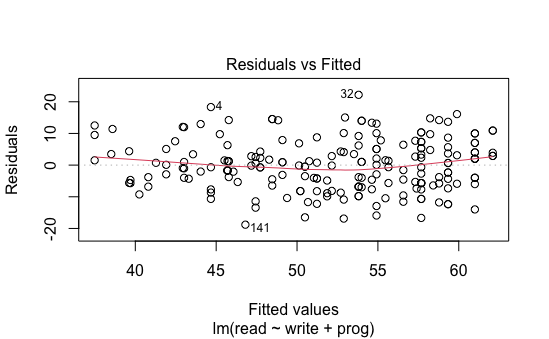

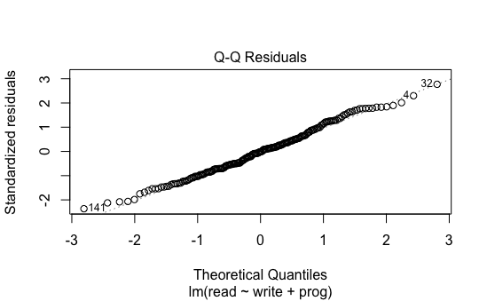

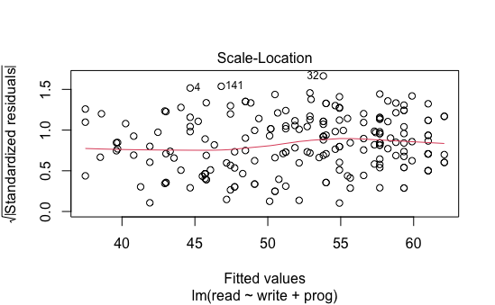

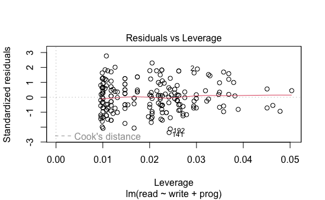

QQplot : Our residuals follow normal distribution (most of the points lie on the line)

```r
str( summary(lm_simple) )
```

```
List of 11
 $ call         : language lm(formula = read ~ write + prog, data = highschool)
 $ terms        :Classes 'terms', 'formula'  language read ~ write + prog
  .. ..- attr(*, "variables")= language list(read, write, prog)
  .. ..- attr(*, "factors")= int [1:3, 1:2] 0 1 0 0 0 1
  .. .. ..- attr(*, "dimnames")=List of 2
  .. .. .. ..$ : chr [1:3] "read" "write" "prog"
  .. .. .. ..$ : chr [1:2] "write" "prog"
  .. ..- attr(*, "term.labels")= chr [1:2] "write" "prog"
  .. ..- attr(*, "order")= int [1:2] 1 1
  .. ..- attr(*, "intercept")= int 1
  .. ..- attr(*, "response")= int 1
  .. ..- attr(*, ".Environment")=<environment: R_GlobalEnv>
  .. ..- attr(*, "predvars")= language list(read, write, prog)
  .. ..- attr(*, "dataClasses")= Named chr [1:3] "numeric" "numeric" "factor"
  .. .. ..- attr(*, "names")= chr [1:3] "read" "write" "prog"
 $ residuals    : Named num [1:200] 6.88 15.03 4.38 18.33 -6.81 ...
  ..- attr(*, "names")= chr [1:200] "1" "2" "3" "4" ...
 $ coefficients : num [1:4, 1:4] 21.372 0.553 3.684 -1.027 3.614 ...
  ..- attr(*, "dimnames")=List of 2
  .. ..$ : chr [1:4] "(Intercept)" "write" "progacademic" "progvocational"
  .. ..$ : chr [1:4] "Estimate" "Std. Error" "t value" "Pr(>|t|)"
 $ aliased      : Named logi [1:4] FALSE FALSE FALSE FALSE
  ..- attr(*, "names")= chr [1:4] "(Intercept)" "write" "progacademic" "progvocational"
 $ sigma        : num 8.05
 $ df           : int [1:3] 4 196 4
 $ r.squared    : num 0.393
 $ adj.r.squared: num 0.383
 $ fstatistic   : Named num [1:3] 42.2 3 196
  ..- attr(*, "names")= chr [1:3] "value" "numdf" "dendf"
 $ cov.unscaled : num [1:4, 1:4] 0.20144 -0.00349 -0.00503 -0.03819 -0.00349 ...
  ..- attr(*, "dimnames")=List of 2
  .. ..$ : chr [1:4] "(Intercept)" "write" "progacademic" "progvocational"
  .. ..$ : chr [1:4] "(Intercept)" "write" "progacademic" "progvocational"
 - attr(*, "class")= chr "summary.lm"
```

coefficients : num [1:4, 1:4] ==> 4x4 matrix

In this case the fit coefficients can be accessed from the fit summary using $coefficients[].

```r
B1 <- summary(lm_simple)$coefficients[2,1] # write coefficient
B2 <- summary(lm_simple)$coefficients[3,1] # progacademic coefficient
B3 <- summary(lm_simple)$coefficients[4,1] # progvocational coefficient
```

To use the bootstrap method to explore how the coefficients change when the dataset is resampled, we follow the method from above, but this time select rows from the original dataset at random, with the sample_n function:

```r
n_repeats <- 100

B1_vals <- rep(0, n_repeats)
B2_vals <- rep(0, n_repeats)
B3_vals <- rep(0, n_repeats)

n <- nrow(highschool)

for (i in 1:n_repeats){
  highschool_bstrap <- sample_n(highschool, size = 200, replace=T )
  lm_simple <- lm(read ~ write + prog, data=highschool_bstrap)

  B1 <- summary(lm_simple)$coefficients[2,1]
  B2 <- summary(lm_simple)$coefficients[3,1]
  B3 <- summary(lm_simple)$coefficients[4,1]

  B1_vals[i] <- B1
  B2_vals[i] <- B2
  B3_vals[i] <- B3
}

B1_sd <- sd(B1_vals)
B2_sd <- sd(B2_vals)
B3_sd <- sd(B3_vals)
```

sample_n ==> selecting rows from dataframes not js data use bootstrapped sample

actually attain vs theory suggests

```r
paste("coef: bootstrap SD : lm fit estimate SE")
```

```
[1] "coef: bootstrap SD : lm fit estimate SE"
```

```r
paste( "B1:  ",round(sd(B1_vals),3),"       :",round(summary(lm_simple)$coefficients[2,2],3))
```

```
[1] "B1:   0.057        : 0.061"
```

```r
paste( "B2:  ",round(sd(B2_vals),3),"       :",round(summary(lm_simple)$coefficients[3,2],3))
```

```
[1] "B2:   1.533        : 1.216"
```

```r
paste( "B3:  ",round(sd(B3_vals),3),"       :",round(summary(lm_simple)$coefficients[4,2],3))
```

```
[1] "B3:   1.869        : 1.492"
```